# OLDW - Prophet Model for Coursera Courses

# Further Attempt - Look at course individually

#### 1. Successful Negotiation: Essential Strategies and Skills

This one is a teach-out course, so we’ll just ignore it.

#### 2. Community Organizing for Social Justice

```r
course = "Community Organizing for Social Justice"
tune_par(course, 20, 0, 30, 0, 10)
```

After further tuning, MAPE improved by 0.96%.

|  | changepoint.prior.scale | seasonality.prior.scale | MAPE |
| --- | --- | --- | --- |
| Baseline Model | 0.05 | 10 | 11.84 |
| 2nd Model | 8.19 | 0.02 | 10.88 |
| 3rd Model | 12.7 | 9.5 | 11.61 |

#### 3. The Finite Element Method for Problems in Physics

```r
course = "The Finite Element Method for Problems in Physics"
tune_par(course, 10, 0, 30, 0, 10)
```

After further tuning, MAPE improved by 4.25%.

[output not shown]

#### 4. Applied Social Network Analysis in Python

```r
course = "Applied Social Network Analysis in Python"
dt = dt_coursera[CRSE_NM==course, .(ds, CNT, y)]
mod = prophet(dt[, .(ds, y)], algorithm="LBFGS")
future = make_future_dataframe(mod, periods = 30, freq = "day")
forecast = predict(mod, future)
datatable(dt)
```

|  | ds | CNT | y |
| --- | --- | --- | --- |
| 1 | 2017-08-15 | 98 | 106 |
| 2 | 2017-08-16 | 16 | 122 |
| 3 | 2017-08-17 | 5 | 127 |
| 4 | 2017-08-18 | 3 | 130 |
| 5 | 2017-08-19 | 1 | 131 |
| 6 | 2017-08-20 | 4 | 135 |
| 7 | 2017-08-21 | 5 | 140 |
| 8 | 2017-08-22 | 3 | 143 |
| 9 | 2017-08-23 | 1 | 144 |
| 10 | 2017-08-25 | 1 | 145 |

[output cut: 1025 more lines]

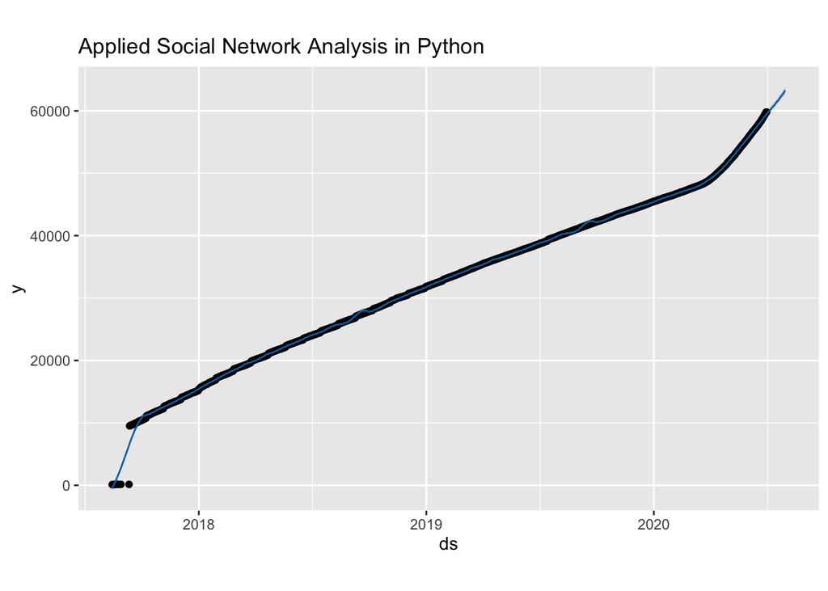

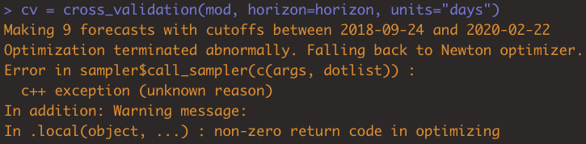

```r
plot(mod, forecast) + ggtitle(course)
```

# Conclusion

Below shows the best result of each course.

```r
new = dt_tune[(dt_tune$mape_imp > 0) & (mape_new < 10),
              .(course, mape=mape_new)]
df_final = rbind(tbl[!(tbl$course %in% new$course), c("course", "mape")],
                 new) %>% arrange(mape)
rownames(df_final) = 1:nrow(df_final)
df_final[df_final$course == "Community Organizing for Social Justice",
         "mape"] = 10.88
df_final[df_final$course == "The Finite Element Method for Problems in Physics",
         "mape"] = 6.39
df_final = df_final[-nrow(df_final),]
datatable(df_final)
```

|  | course | mape |
| --- | --- | --- |
| 1 | Managing Talent | 0.94 |
| 2 | Instructional Methods in Health Professions Education | 1 |
| 3 | Interactivity with JavaScript | 1.22 |
| 4 | Sampling People, Networks and Records | 1.25 |
| 5 | Leading Teams | 1.39 |
| 6 | Introduction to CSS3 | 1.4 |
| 7 | Inspiring and Motivating Individuals | 1.52 |
| 8 | Introduction to Thermodynamics: Transferring Energy from Here to There | 1.53 |
| 9 | Applied Text Mining in Python | 1.55 |
| 10 | Data Collection: Online, Telephone and Face-to-face | 1.66 |

[output cut: 67 more lines]

# References

- Implementing Facebook Prophet efficiently. https://towardsdatascience.com/implementing-facebook-prophet-efficiently-c241305405a3
- Inconsistent diagnosis and how to improve MAPE. https://github.com/facebook/prophet/issues/1058

**Links for better understand prophet**

- Why do we need to fit the model before doing cross validation? https://github.com/facebook/prophet/issues/1409
- Hyperparameter Tuning Snippet. https://github.com/facebook/prophet/issues/1381
- Effect of changepoint_prior_scale and seasonality_prior_scale. https://github.com/facebook/prophet/issues/1320